# How does speed training affect 400 meter PRs?

2024-06-06

this data comes from the 2023-2024 season for the Pomona-Pitzer Track and Field team (men and women). the data is made up of splits taken from an electronic timing system that the 400 group (which i am a part of) uses during our speed training. the goal of this endeavor is to see how speed training affects 400 performance.

i want to note that this is mostly for the sake of practice in playing with data, and not in making hard conclusions. while i may be able to find some correlations, causation is not possible to conclude given the tiny size of the data set and countless confounding variables. it is hard to know whether a split or a race time is slow because an athlete is sick, injured, sleep-deprived, stressed, or if the training is not working. hopefully the effects of these confounding variables is minimized by me focusing on only our best performances, but I want to be sure to name them nonetheless.

also, a note about the data: a standing 30 meter time means that the athlete runs 30 meters from a standing start. it is a good measure of acceleration. a flying 30 meter time means that the athlete has some amount of distance to get up to speed, and then runs 30 meters, essentially measuring their max velocity.

## the data

```r
four_hund_data <- read.csv("/Users/sambutler/Desktop/400 Data - Sheet1.csv")
```

# question 1

how do both standing and flying 30 meter times correspond to 400 performance?

```r
# first find average of five fastest times in each 30m category
thirties <- four_hund_data[, grep("30", names(four_hund_data))]

# replace "NA" with 0 so that we can order the columns
thirties[is.na(thirties)] <- 0

ordered_thirties <- as.data.frame(apply(thirties, 2, sort))

# finding the 5 lowest values
find_five_lowest_non_zero <- function(column_data) {
  non_zero_values <- column_data[column_data != 0]
  sorted_values <- sort(non_zero_values)
  five_lowest_values <- head(sorted_values, 5)
  return(five_lowest_values)
}

fastest_five <- apply(ordered_thirties, 2, find_five_lowest_non_zero)

# in order to find the average of the fastest five, we need all vectors to actually be five values
# finding the max_length
max_length <- max(sapply(fastest_five, length))

# pad vectors with NAs to make them equal length
padded_list <- lapply(fastest_five, function(x) {
  length(x) <- max_length
  return(x)
})

# convert padded list to dataframe
fastest_five_df <- data.frame(padded_list)

# now we can calculate the averages
top_five_avgs <- colMeans(fastest_five_df, na.rm = TRUE)

top_five_avgs_df <- data.frame(top_five_avgs)
```

now we can get our 400 performances

```r
four_hundreds <- four_hund_data[, grep("400", names(four_hund_data))]

# get the fastest performances
min_values <- apply(four_hundreds, 2, min, na.rm = TRUE)

fastest_four_hundreds <- data.frame(min_values)
```

```r
# want to make a dataframe that allows us to compare 30s and 400s
stand_thirties <- top_five_avgs_df[seq(1, nrow(top_five_avgs_df), by = 2), ]
fly_thirties <- top_five_avgs_df[seq(2, nrow(top_five_avgs_df), by = 2), ]

fastest_stand_thirties <- data.frame(stand_thirties)
fastest_fly_thirties <- data.frame(fly_thirties)


total_df <- cbind(fastest_four_hundreds, fastest_stand_thirties, fastest_fly_thirties) %>%
  mutate(athletes = c("Sam", "Jake", "Fox", "Jalen", "Rylan", "Seb", "Olivia", "Nicole", "Kensi", "Anna"))
```

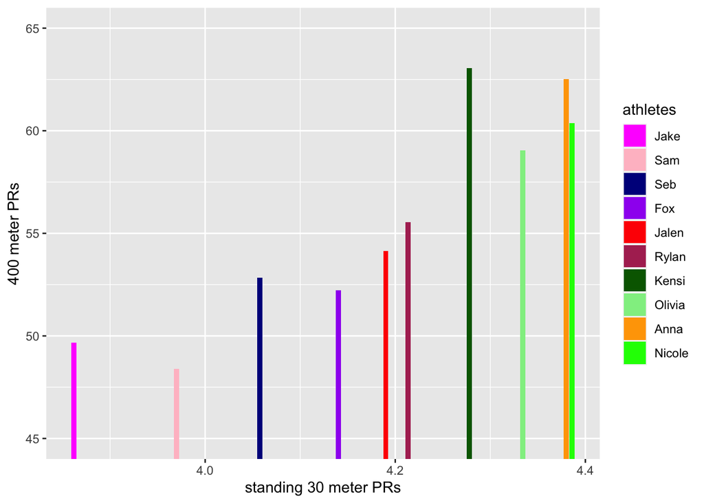

```r
total_df %>%
  ggplot() +
  geom_col(aes(x = stand_thirties, y = min_values, fill = athletes)) +
scale_fill_manual(values = c("Sam" = "pink", "Jake" = "magenta", "Fox" = "purple", "Seb" = "darkblue", "Jalen" = "red", "Rylan" = "maroon", "Olivia" = "lightgreen", "Nicole" = "green", "Kensi" = "darkgreen", "Anna" = "orange"),
                     breaks = c("Jake", "Sam",  "Seb", "Fox", "Jalen", "Rylan", "Kensi", "Olivia", "Anna", "Nicole")) +
  xlab("standing 30 meter PRs") +
  ylab("400 meter PRs") +
  coord_cartesian(ylim = c(45, 65))
```

athletes with lower bars relative to those clustered around them, (Sam, Fox, & Olivia), are more “strength based” athletes. they have better 400 meter PRs with the same acceleration as those around them. so it is likely that their strength comes from somewhere else.

now we might want to see how fly 30 Meter times compare to 400 meter PRs. since the fly times tell us more about max velocity than they do about acceleration, they might be more informative.

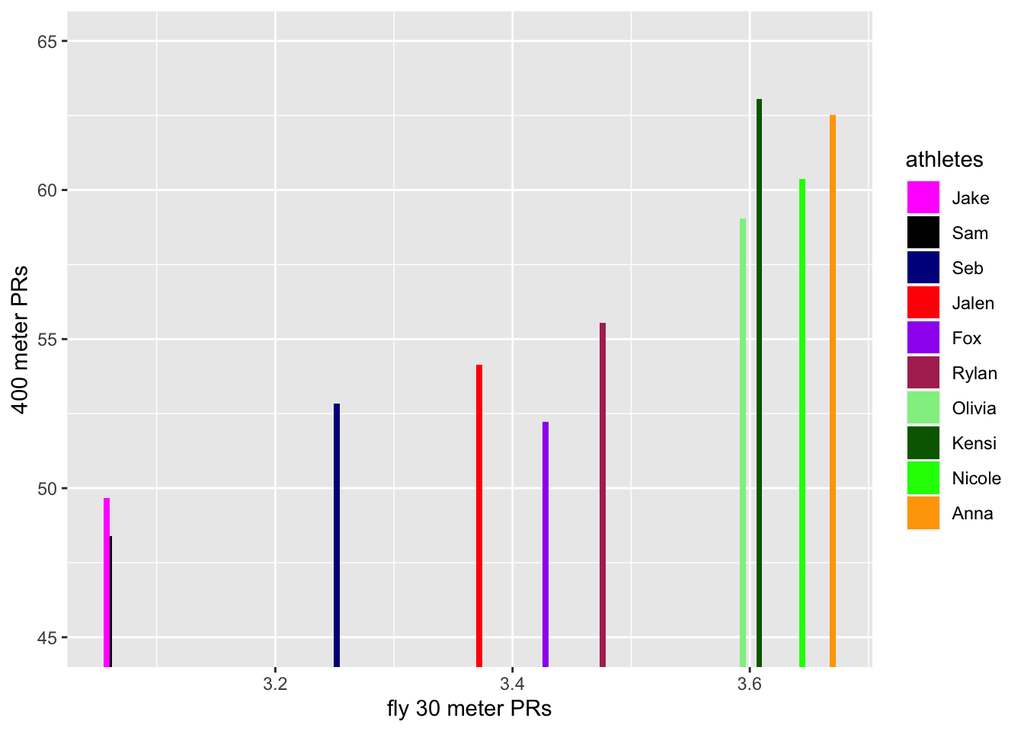

```r
total_df %>%
  ggplot() +
  geom_col(aes(x = fly_thirties, y = min_values, fill = athletes), width = 0.005) +
  scale_fill_manual(values = c("Sam" = "black", "Jake" = "magenta", "Fox" = "purple", "Seb" = "darkblue", "Jalen" = "red", "Rylan" = "maroon", "Olivia" = "lightgreen", "Nicole" = "green", "Kensi" = "darkgreen", "Anna" = "orange"),
                     breaks = c("Jake", "Sam", "Seb", "Jalen", "Fox", "Rylan", "Olivia", "Kensi", "Nicole", "Anna")) +
  xlab("fly 30 meter PRs") +
  ylab("400 meter PRs") +
  coord_cartesian(ylim = c(45, 65))
```

here, we see a similar trend. athletes who are lower than those around them have a faster 400 meter PR with essentially the same max velocity. similarly to the last plot, this indicates that the strength of those athletes might come more from aerobic ability than from speed.

```r
praise()
```

```
## [1] "You are pioneering!"
```